# Survival Analysis in R Companion

Dimitris Rizopoulos

January 18, 2021

# 1 Introduction and Set-Up

This document provides background information on the R code used in the survival analysis part of the Biostatistics Methods II course.

We start by loading the packages that we will require during these illustrations. These are packages **survival**, **splines**, **lattice** and **JM**. The first three packages are recommended packages and exist by default in all R installations. Package **JM** though is an optional package. If you do not have it already installed, you will need to install it. The command to do this is `install.packages("JM")` and needs to be performed only once.

Assuming that all packages are installed, the following commands load them into the active R session:

```r
library("survival")
library("splines")
library("lattice")
library("JM")
```

Next, we load the datasets that we will need for our illustrations, namely the AIDS, PBC, Lung and Stanford datasets introduced in the main slides of the course. These datasets are available as objects `aids.id`, `pbc2.id`, `lung` and `stanford2`, respectively. The first two from package **JM** and the last two from package **survival**. To load the datasets from the packages we use the `data()` function, i.e.,

```r
data("aids", package = "JM")
data("aids.id", package = "JM")
data("pbc2.id", package = "JM")
data("lung", package = "survival")
data("stanford2", package = "survival")
```

For the `lung` dataset we also need to perform two data management steps, in particular, to specify variable `sex` as a factor, and to remove the missing values from the variables we will later use. The relevant commands are:

```r
lung$sex <- factor(lung$sex, levels = 1:2, labels = c("male", "female"))
lung <- with(lung, lung[complete.cases(time, status, sex, age, ph.karno), ])
```

Back to top

# 2 Basic Survival Analysis

## 2.1 Estimators of the Survival Function

A key function for the analysis of survival data in R is function `Surv()`. This is used to specify the type of survival data that we have, namely, right censored, left censored, interval censored. For our illustrations, we will only consider right censored data. In this case, function `Surv()` accepts as first argument the observed survival times, and as second the event indicator. Function `Surv()` is used by many other functions we will see later.

The function that is used to calculate the Kaplan-Meier estimate is `survfit()`. Its first argument is an R `formula`. The left-hand side of this formula specifies the survival times information using function `Surv()`, and the right-hand side is used to specify grouping variables (e.g., if we would like to obtain separate estimates of the survival function per treatment group) – if we put ‘1’ as below, then one survival curve is estimated based on all the data. Argument `data` specifies the data frame that contains the variables of interest. For the Stanford data, we obtain the Kaplan-Meier estimator using the command:

```r
KM_fit <- survfit(Surv(time, status) ~ 1, data = stanford2)
KM_fit
```

```
## Call: survfit(formula = Surv(time, status) ~ 1, data = stanford2)
##
##       n  events  median 0.95LCL 0.95UCL
##     184     113     631     328    1232
```

The basic output of function `survfit()` gives the number of subjects, the number of events, the median survival time and its 95% confidence interval. Using the `summary()` method and its `times` argument we can obtain the survival probabilities at specific follow-up times. For example, the following code computes the survival probabilities at 1000 and 2000 days:

```r
summary(KM_fit, times = c(1000, 2000))
```

```
## Call: survfit(formula = Surv(time, status) ~ 1, data = stanford2)
##
##  time n.risk n.event survival std.err lower 95% CI upper 95% CI
##  1000     52      94    0.443  0.0396        0.372        0.528
##  2000     15      15    0.274  0.0440        0.200        0.375
```

The `quantile()` method computes the corresponding follow-up times at which the survival probability takes a specific value. For example, we want to find at how many days the survival probability equals 0.7 and at how many days it equals 0.6 – the code is:

```r
quantile(KM_fit, probs = 1 - c(0.7, 0.6))
```

```
## $quantile
##  30  40
## 136 274
##
## $lower
##  30  40
##  65 148
##
## $upper
##  30  40
## 227 623
```

Note that in the `probs` argument of `quantile()` we have to specify one minus our target survival probabilities; this is because the function works under the cumulative distribution function (CDF) convention, and the CDF equals one minus survival probability. Moreover, also note that we obtain the lower and upper limits of the 95% confidence intervals for the quantiles we have asked.

The `plot()` method produces the figure of the estimated curve; by default, the 95% confidence interval is included when we have only one curve:

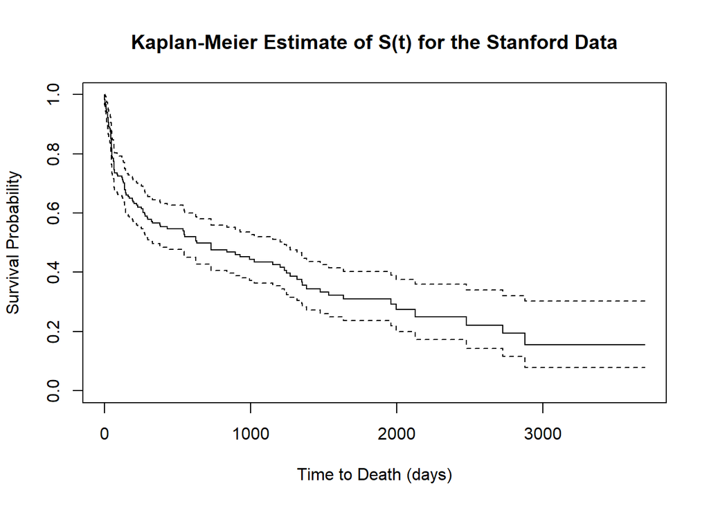

```r
plot(KM_fit, xlab = "Time to Death (days)", ylab = "Survival Probability",
    main = "Kaplan-Meier Estimate of S(t) for the Stanford Data")
```

To calculate the Breslow estimator, we use again function `survfit()` with the same syntax as for the Kaplan-Meier estimator – the only difference is that we now need to set argument `type` to `"fleming-harrington"`. For the Stanford data we have:

```r
Br_fit <- survfit(Surv(time, status) ~ 1, data = stanford2,
    type = "fleming-harrington")
Br_fit
```

```
## Call: survfit(formula = Surv(time, status) ~ 1, data = stanford2, type = "fleming-harrington")
##
##       n  events  median 0.95LCL 0.95UCL
##     184     113     729     328    1232
```

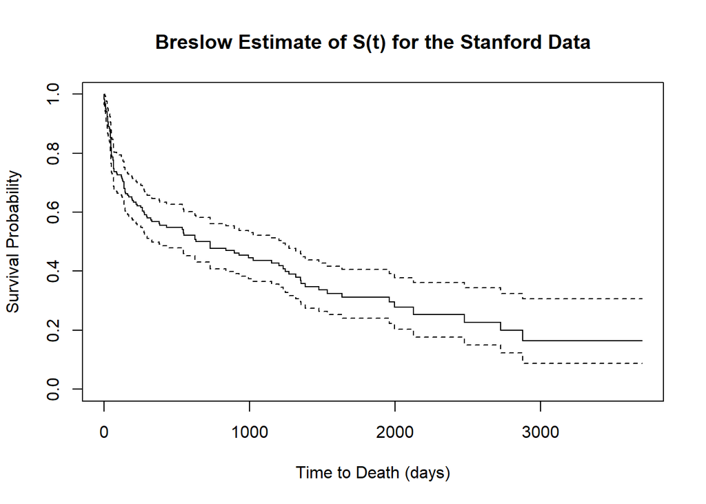

```r
plot(Br_fit, mark.time = FALSE, xlab = "Time to Death (days)",
    ylab = "Survival Probability",
    main = "Breslow Estimate of S(t) for the Stanford Data")
```

The interpretation of the output, as well as functions `summary()` and `quantile()` work in the same manner as in the examples we have seen above for the Kaplan-Meier estimator.

Back to top

## 2.2 Statistical Tests

We have two standard statistical tests for testing simple hypothesis with one grouping variable (i.e., to test the hypothesis whether the survival functions of different groups of subjects differ statistically significantly). The first and most widely used test is the log-rank test. This test is performed in R using function `survdiff()`. For example, to test with the log-rank test whether there are differences in the survival rates in the Lung dataset between males and females, we use the code:

```r
logrank <- survdiff(Surv(time, status == 2) ~ sex, data = lung)
logrank
```

```
## Call:
## survdiff(formula = Surv(time, status == 2) ~ sex, data = lung)
##
##              N Observed Expected (O-E)^2/E (O-E)^2/V
## sex=male   137      111     90.9      4.42        10
## sex=female  90       53     73.1      5.51        10
##
##  Chisq= 10  on 1 degrees of freedom, p= 0.002
```

We have found a strong indication of a difference between the two groups. To test the same hypothesis but with the Peto & Peto Gehan-Wilcoxon test, we use the `survdiff()` function again, but now we set argument `rho` to 1:

```r
peto_peto <- survdiff(Surv(time, status == 2) ~ sex, data = lung, rho = 1)
peto_peto
```

```
## Call:
## survdiff(formula = Surv(time, status == 2) ~ sex, data = lung,
##     rho = 1)
##
##              N Observed Expected (O-E)^2/E (O-E)^2/V
## sex=male   137     69.7     55.2      3.83      12.3
## sex=female  90     28.8     43.4      4.88      12.3
##
##  Chisq= 12.3  on 1 degrees of freedom, p= 4e-04
```

The conclusion remains the same with a p-value of a smaller magnitude.

The log-rank test is the most powerful test when the proportional hazards (PH) assumption is satisfied. To check this assumption, we can plot the cumulative hazard functions for the two groups; when PH is satisfied the two curves will be proportional to each other (i.e., the steadily grow away of each other). The cumulative hazards plot can be produced by the `plot()` method for `survfit()` objects using the `fun` argument, e.g.,

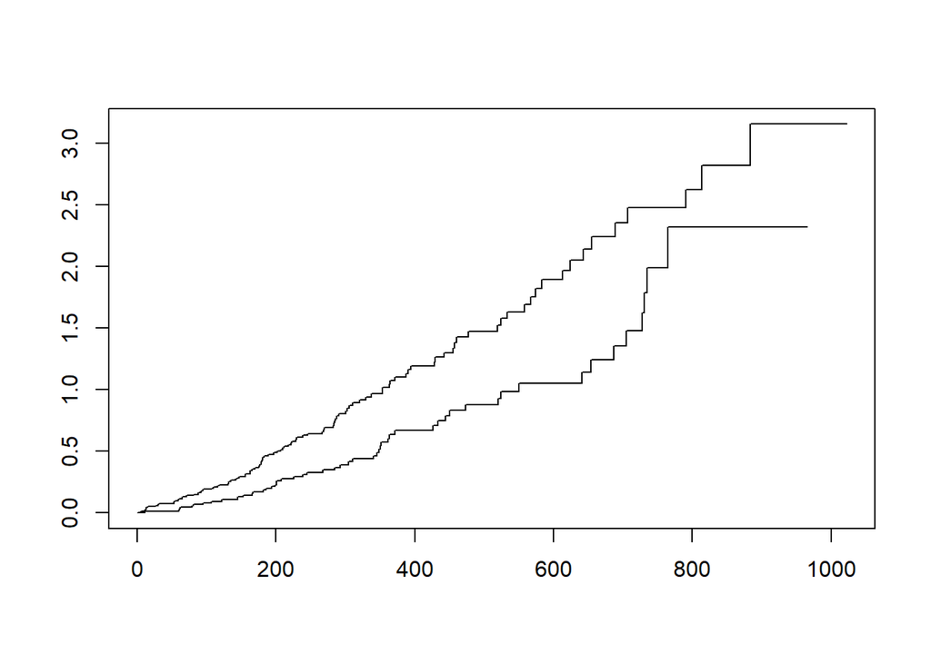

```r
KM_fit <- survfit(Surv(time, status == 2) ~ sex, data = lung)
plot(KM_fit, fun = "cumhaz")
```

Back to top

# 3 Accelerated Failure Time Models

## 3.1 Model Fitting

The function that fits AFT models from the **survival** package is `survreg()`. Its first argument is a formula and has a similar syntax as the function `survfit()`. The `dist` argument specifies the distribution for the survival times (**Note:** the `dist` argument specifies the distribution of the survival times *not* the log survival times). The default distribution (i.e., if you do not specify the `dist` argument yourself) is the Weibull distribution. As with other model fitting functions in R, the `summary()` function returns a detailed output of the fitted model. As an example, we fit an AFT model assuming the Weibull distribution for the PBC dataset. We control for `drug`, `sex` and `age`. The code is:

```r
fit_weibull <- survreg(Surv(years, status2) ~ drug + sex + age, data = pbc2.id)

summary(fit_weibull)
```

```
##
## Call:
## survreg(formula = Surv(years, status2) ~ drug + sex + age, data = pbc2.id)
##                  Value Std. Error     z      p
## (Intercept)    4.13862    0.48260  8.58 <2e-16
## drugD-penicil  0.13046    0.15576  0.84  0.402
## sexfemale      0.44472    0.20147  2.21  0.027
## age           -0.03874    0.00793 -4.89  1e-06
## Log(scale)    -0.10223    0.07423 -1.38  0.168
##
## Scale= 0.903
##
## Weibull distribution
## Loglik(model)= -494.7   Loglik(intercept only)= -511.8
##  Chisq= 34.23 on 3 degrees of freedom, p= 1.8e-07
## Number of Newton-Raphson Iterations: 5
## n= 312
```

To fit the same model but with the exponential distribution, the code is:

```r
fit_exp <- survreg(Surv(years, status2) ~ drug + sex + age, data = pbc2.id,
                   dist = "exponential")

summary(fit_exp)
```

```
##
## Call:
## survreg(formula = Surv(years, status2) ~ drug + sex + age, data = pbc2.id,
##     dist = "exponential")
##                 Value Std. Error     z       p
## (Intercept)    4.3282     0.5159  8.39 < 2e-16
## drugD-penicil  0.1438     0.1721  0.84    0.40
## sexfemale      0.4816     0.2217  2.17    0.03
## age           -0.0420     0.0084 -5.00 5.7e-07
##
## Scale fixed at 1
##
## Exponential distribution
## Loglik(model)= -495.6   Loglik(intercept only)= -512.3
##  Chisq= 33.35 on 3 degrees of freedom, p= 2.7e-07
## Number of Newton-Raphson Iterations: 4
## n= 312
```

To fit the same model but with the log-normal distribution, the code is:

```r
fit_lnorm <- survreg(Surv(years, status2) ~ drug + sex + age, data = pbc2.id,
                   dist = "lognormal")

summary(fit_lnorm)
```

```
##
## Call:
## survreg(formula = Surv(years, status2) ~ drug + sex + age, data = pbc2.id,
##     dist = "lognormal")
##                  Value Std. Error     z       p
## (Intercept)    4.41534    0.59602  7.41 1.3e-13
## drugD-penicil  0.21196    0.18775  1.13    0.26
## sexfemale      0.30242    0.27761  1.09    0.28
## age           -0.04841    0.00944 -5.13 2.9e-07
## Log(scale)     0.34711    0.06473  5.36 8.2e-08
##
## Scale= 1.41
##
## Log Normal distribution
## Loglik(model)= -498.9   Loglik(intercept only)= -515.2
##  Chisq= 32.72 on 3 degrees of freedom, p= 3.7e-07
## Number of Newton-Raphson Iterations: 3
## n= 312
```

To fit the same model but with the log-logistic distribution, the code is:

```r
fit_llogis <- survreg(Surv(years, status2) ~ drug + sex + age, data = pbc2.id,
                   dist = "loglogistic")

summary(fit_llogis)
```

```
##
## Call:
## survreg(formula = Surv(years, status2) ~ drug + sex + age, data = pbc2.id,
##     dist = "loglogistic")
##                  Value Std. Error     z       p
## (Intercept)    4.00019    0.54926  7.28 3.3e-13
## drugD-penicil  0.14532    0.17387  0.84 0.40325
## sexfemale      0.38446    0.24161  1.59 0.11155
## age           -0.04151    0.00884 -4.69 2.7e-06
## Log(scale)    -0.26129    0.07326 -3.57 0.00036
##
## Scale= 0.77
##
## Log logistic distribution
## Loglik(model)= -497.4   Loglik(intercept only)= -513
##  Chisq= 31.08 on 3 degrees of freedom, p= 8.2e-07
## Number of Newton-Raphson Iterations: 4
## n= 312
```

Back to top

## 3.2 Effect Plots

In cases we consider statistical models with complex terms (interactions and nonlinear terms), the regression coefficients we obtain in the output do not have a straightforward interpretation. In these settings, we can use effect plots to communicate the results of the model. As an example, we fit a model in the PBC dataset that contains the effect of `drug`, the effect of `sex`, the linear effect of `age`, the quadratic effect of `age`, and the interaction effects between `sex` and the linear and quadratic effects of `age`, and between `drug` and the linear and quadratic effects of `age`. We assume that the survival times follow the Weibull distribution. The code to fit the model is:

```r
fit <- survreg(Surv(years, status2) ~ (drug + sex) * (age + I(age^2)),
               data = pbc2.id)

summary(fit)
```

```
##
## Call:
## survreg(formula = Surv(years, status2) ~ (drug + sex) * (age +
##     I(age^2)), data = pbc2.id)
##                            Value Std. Error     z    p
## (Intercept)             8.342101   6.266023  1.33 0.18
## drugD-penicil           3.489874   3.353680  1.04 0.30
## sexfemale              -6.523710   6.189094 -1.05 0.29
## age                    -0.161596   0.217081 -0.74 0.46
## I(age^2)                0.000822   0.001843  0.45 0.66
## drugD-penicil:age      -0.148887   0.127901 -1.16 0.24
## drugD-penicil:I(age^2)  0.001549   0.001197  1.29 0.20
## sexfemale:age           0.240257   0.215642  1.11 0.27
## sexfemale:I(age^2)     -0.002015   0.001847 -1.09 0.28
## Log(scale)             -0.113198   0.074516 -1.52 0.13
##
## Scale= 0.893
##
## Weibull distribution
## Loglik(model)= -492.4   Loglik(intercept only)= -511.8
##  Chisq= 38.81 on 8 degrees of freedom, p= 5.3e-06
## Number of Newton-Raphson Iterations: 5
## n= 312
```

As mentioned above, in this particular example, the linear and quadratic effects of age, and the corresponding interactions effects cannot be easily interpreted. To visualize the model, we will use an effects plot. The first step is to specify a dataset that contains combinations of values for the covariates of the model based on which we will create the plot. In our example, we can create a single figure with all possible combinations of the covariates, i.e., both treatment groups, both sexes and increasing age. To create the dataset that contains all possible combinations of these covariates we use function `expand.grid()`. The code is:

```r
ND <- with(pbc2.id, expand.grid(
    age = seq(30, 65, length.out = 25),
    sex = levels(sex),
    drug = levels(drug)
))

head(ND, 10)
```

```
##         age  sex    drug
## 1  30.00000 male placebo
## 2  31.45833 male placebo
## 3  32.91667 male placebo
## 4  34.37500 male placebo
## 5  35.83333 male placebo
## 6  37.29167 male placebo
## 7  38.75000 male placebo
## 8  40.20833 male placebo
## 9  41.66667 male placebo
## 10 43.12500 male placebo
```

Function `seq()` creates a sequence of numbers, in our example from 30 to 65 years old, with the length of the sequence equal to 25. Function `levels()` extracts from the `pbc2.id` database the possible values of the `sex` and `drug` variables. Function `head()` prints the first ten rows of this dataset. **Note:** In the definition of the data frame `ND`, all variables that appear in the model need to have their values specified. Also, you need to respect the class of these variables, e.g., in the example above and in the original data frame `pbc2.id`, variable `sex` is a factor. This is why we define its levels in `ND` and not, for example, the values 0 and 1.

Next, based on this dataset we compute the predictions from the model using function `predict()`:

```r
prs <- predict(fit, ND, se.fit = TRUE, type = "lp")
ND$pred <- prs[[1]]
ND$se <- prs[[2]]
ND$lo <- ND$pred - 1.96 * ND$se
ND$up <- ND$pred + 1.96 * ND$se

head(ND, 10)
```

```
##         age  sex    drug     pred        se       lo       up
## 1  30.00000 male placebo 4.234429 1.4533787 1.385807 7.083051
## 2  31.45833 male placebo 4.072483 1.3055301 1.513644 6.631322
## 3  32.91667 male placebo 3.914035 1.1659479 1.628777 6.199293
## 4  34.37500 male placebo 3.759085 1.0347438 1.730987 5.787183
## 5  35.83333 male placebo 3.607634 0.9120677 1.819981 5.395287
## 6  37.29167 male placebo 3.459681 0.7981221 1.895362 5.024000
## 7  38.75000 male placebo 3.315227 0.6931838 1.956586 4.673867
## 8  40.20833 male placebo 3.174270 0.5976336 2.002909 4.345632
## 9  41.66667 male placebo 3.036812 0.5119939 2.033304 4.040321
## 10 43.12500 male placebo 2.902853 0.4369676 2.046396 3.759309
```

The output of the `predict()` function as specified above is the predictions (in the log survival times scale) and the corresponding standard errors. The second and third lines of the code include as extra columns in the dataset `ND` these predictions and standard errors. The fourth and fifth lines calculate the lower and upper limits of a 95% confidence interval for the log survival times. Finally, we create the plot using function `xyplot()` from package **lattice**:

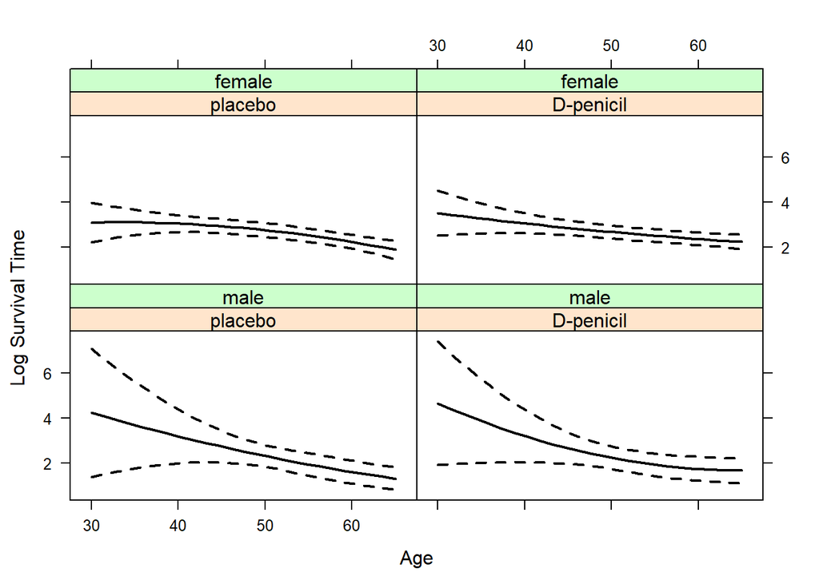

```r
xyplot(pred + lo + up ~ age | drug*sex, data = ND, type = "l",
    lty = c(1,2,2), col = "black", lwd = 2, xlab = "Age",
    ylab = "Log Survival Time")
```

To create the plot for only one level of a categorical covariate, we use function `factor()` in the definition of the dataset `ND` in order to denote that this variable has two levels but only one of them is used. As an example, we recreate the plot from above but only for females. The specification of `ND` becomes:

```r
ND <- with(pbc2.id, expand.grid(
    age = seq(30, 65, length.out = 25),
    sex = factor("female", levels = levels(sex)),
    drug = levels(drug)
))

head(ND, 10)
```

```
##         age    sex    drug
## 1  30.00000 female placebo
## 2  31.45833 female placebo
## 3  32.91667 female placebo
## 4  34.37500 female placebo
## 5  35.83333 female placebo
## 6  37.29167 female placebo
## 7  38.75000 female placebo
## 8  40.20833 female placebo
## 9  41.66667 female placebo
## 10 43.12500 female placebo
```

The rest of the code remains the same; the only extra difference is that we now do the plot in the original timescale and not for the log survival times - note the use of function `exp()` in the code below, i.e.,

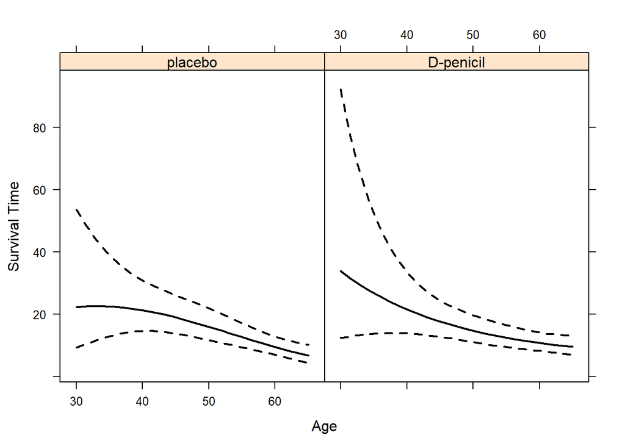

```r
prs <- predict(fit, ND, se.fit = TRUE, type = "lp")
ND$pred <- prs[[1]]
ND$se <- prs[[2]]
ND$lo <- exp(ND$pred - 1.96 * ND$se)
ND$up <- exp(ND$pred + 1.96 * ND$se)
ND$pred <- exp(ND$pred)

xyplot(pred + lo + up ~ age | drug, data = ND, type = "l",
    lty = c(1,2,2), col = "black", lwd = 2, xlab = "Age",
    ylab = "Survival Time")
```

Back to top

## 3.3 Hypothesis Testing

A statistical comparison between two nested models can be performed with a likelihood ratio test calculated by function `anova()`. As an example, we use again the complex model that we used for the effect plot in the previous section, i.e.,

```r
fit_alt <- survreg(Surv(years, status2) ~ (drug + sex) * (age + I(age^2)), data = pbc2.id)
```

Say that we want to test whether we can drop all the complex terms, that is, the interaction and nonlinear terms. Then, the model above is the model under the alternative hypothesis (i.e., the full model). The model under the null hypothesis is the one that does not contain any of these terms (i.e., the reduced model):

```r
fit_null <- survreg(Surv(years, status2) ~ drug + sex + age, data = pbc2.id)
```

We compare the two models using `anova()`, i.e.,

```r
anova(fit_null, fit_alt)
```

```
##                             Terms Resid. Df    -2*LL Test Df Deviance  Pr(>Chi)
## 1                drug + sex + age       307 989.4673      NA       NA        NA
## 2 (drug + sex) * (age + I(age^2))       302 984.8867    =  5 4.580586 0.4691742
```

**Note** that the user is responsible to supply appropriately nested AFT models such that the LRT to be valid. The result suggests that we could use the simplified model.

Back to top

## 3.4 Residuals

In order to check whether the assumed distribution of survival times fits the observed data sufficiently well, we can use the residuals of the model. However, because the residuals are calculated based on the observed event times, they will also be censored. Hence, to investigate whether they follow a particular distribution, we will need to employ a graphical procedure accounting for censoring. One way to achieve this is by using the Kaplan-Meier estimator of the residuals. As an example, we would like to investigate whether the Weibull distribution is an appropriate distribution for the survival times in the AIDS dataset. We first fit the model of interest:

```r
fit_weib <- survreg(Surv(Time, death) ~ drug * gender, data = aids.id)
```

Next, we construct the residuals based on their definition

```r
fitted_values <- fit_weib$linear.predictors
resids <- (log(fit_weib$y[, 1]) - fitted_values) / fit_weib$scale
```

We then compute the Kaplan-Meier estimate of these residuals, and we plot it. Lines 3-5 of the code below are used to superimpose in the graph the assumed Weibull distribution.

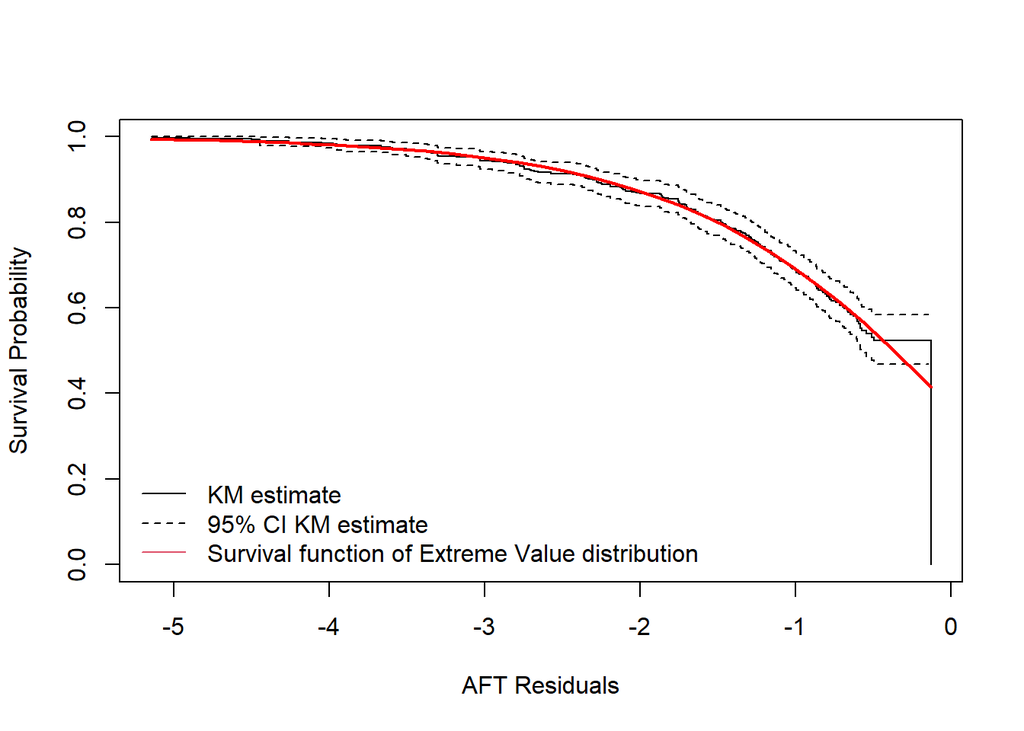

```r
resKM <- survfit(Surv(resids, death) ~ 1, data = aids.id)
plot(resKM, mark.time = FALSE, xlab = "AFT Residuals", ylab = "Survival Probability")
xx <- seq(min(resids), max(resids), length.out = 35)
yy <- exp(- exp(xx))
lines(xx, yy, col = "red", lwd = 2)
legend("bottomleft", c("KM estimate", "95% CI KM estimate",
    "Survival function of Extreme Value distribution"),
    lty = c(1,2,1), col = c(1,1,2), bty = "n")
```

In this example, we observe that the Weibull distribution provides a good fit to the data. For models that assume other distributions of the survival times, the only thing that we need to change is the line of the code where the `yy` values are defined. In particular, for AFT models assuming the log-normal or the Gaussian distribution, we use `yy <- pnorm(xx, lower.tail = FALSE)`, and for AFT models assuming the log-logistic or the logistic distribution, you should use `yy <- plogis(xx, lower.tail = FALSE)`.

Back to top

# 4 Cox Proportional Hazards Models

## 4.1 Model Fitting

The function that fits Cox models from the **survival** package is `coxph()`. It has similar syntax to `survreg()` that we saw in the previous section, with only exception that it does not have the `dist` argument (i.e., the Cox model is a semi-parametric model that does not assume a particular distribution for the survival times). As in the majority of the model fitting functions in R, the `summary()` method returns a detailed output of the fitted model. As an example, we fit a Cox model to the PBC dataset in which we include as covariates the `drug`, `sex` and `age`; the code is:

```r
fit <- coxph(Surv(years, status2) ~ drug + sex + age, data = pbc2.id)
summary(fit)
```

```
## Call:
## coxph(formula = Surv(years, status2) ~ drug + sex + age, data = pbc2.id)
##
##   n= 312, number of events= 140
##
##                    coef exp(coef)  se(coef)      z Pr(>|z|)
## drugD-penicil -0.146013  0.864146  0.172143 -0.848   0.3963
## sexfemale     -0.470905  0.624437  0.221785 -2.123   0.0337 *
## age            0.042842  1.043773  0.008505  5.037 4.72e-07 ***
## ---
## Signif. codes:  0 '***' 0.001 '**' 0.01 '*' 0.05 '.' 0.1 ' ' 1
##
##               exp(coef) exp(-coef) lower .95 upper .95
## drugD-penicil    0.8641     1.1572    0.6167    1.2109
## sexfemale        0.6244     1.6014    0.4043    0.9644
## age              1.0438     0.9581    1.0265    1.0613
##
## Concordance= 0.629  (se = 0.024 )
## Likelihood ratio test= 33.25  on 3 df,   p=3e-07
## Wald test            = 34.87  on 3 df,   p=1e-07
## Score (logrank) test = 35.31  on 3 df,   p=1e-07
```

The column `coef` in the output denotes the log hazard ratios, and `exp(coef)` the corresponding hazard ratios.

Back to top

## 4.2 Effect Plots

Similarly to AFT models, when we consider a more complex model that includes interactions and nonlinear terms, it is more useful to communicate the results of the model using an effects plot. The procedure to construct such a plot is the same as in AFT models. For example, we want to produce an effect plot for the following Cox model for the Lung dataset that contains the `sex` the nonlinear effect of `age` and its interaction with `sex`, and the nonlinear effect of `ph.karno`:

```r
fit <- coxph(Surv(time, status) ~ ns(age, 3) * sex + ns(ph.karno, 3), data = lung)
```

We first construct the dataset that gives the combinations of covariate values based on which the plot will be constructed. This done with function `expand.grid()`:

```r
ND <- with(lung, expand.grid(
    age = seq(45, 75, length.out = 25),
    sex = levels(sex),
    ph.karno = quantile(ph.karno, c(0.25, 0.5, 0.75))
))
head(ND)
```

```
##     age  sex ph.karno
## 1 45.00 male       75
## 2 46.25 male       75
## 3 47.50 male       75
## 4 48.75 male       75
## 5 50.00 male       75
## 6 51.25 male       75
```

In the definition of `ND` all variables that are in the model need to have their values specified - see the relevant note also in the corresponding section in the AFT models. As seen above, we will do the plot, for increasing age from 45 to 75 years old, both males and females, and for `ph.karno` increasing from the 1st quartile, to the median, to the 3rd quartile. Next, we obtain the predictions from the model (these are in the log-hazard scale), and we calculate the 95% confidence interval:

```r
prs <- predict(fit, newdata = ND, type = "lp", se.fit = TRUE)
ND$pred <- prs[[1]]
ND$se <- prs[[2]]
ND$lo <- ND$pred - 1.96 * ND$se
ND$up <- ND$pred + 1.96 * ND$se
ND$ph.karno <- factor(ND$ph.karno, labels = paste("PH Karno =", sort(unique(ND$ph.karno))))
```

The last line of the code transforms the `ph.karno` variable to a factor in order to have a more visible label in the plot that is produced with the following code:

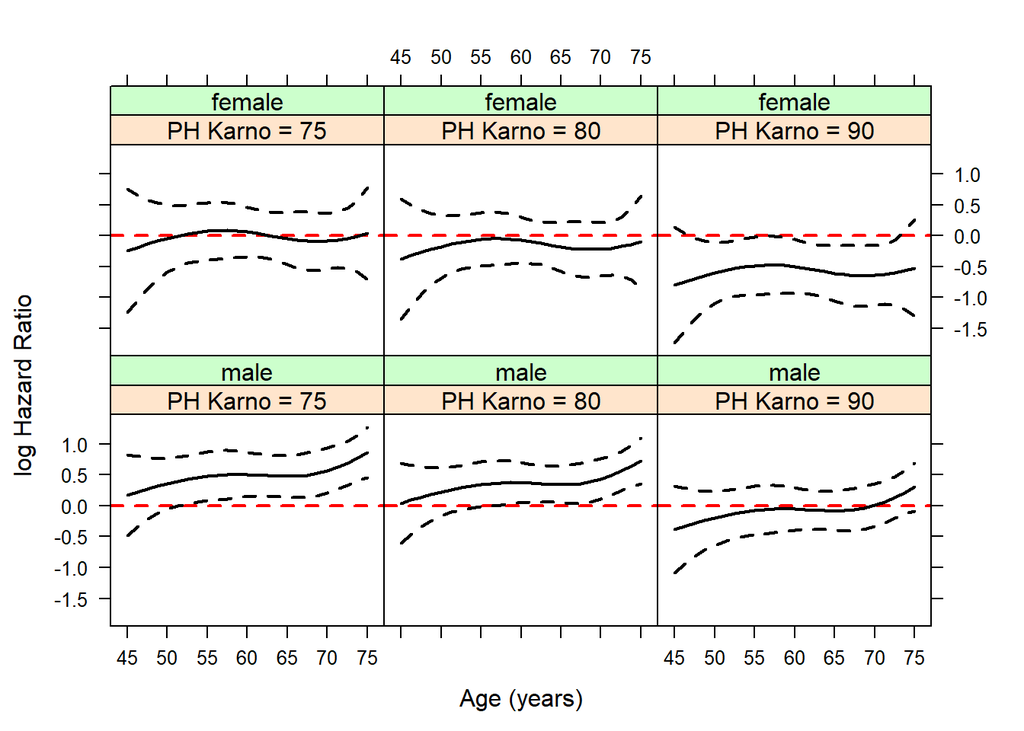

```r
xyplot(pred + lo + up ~ age | ph.karno * sex, data = ND,
       type = "l", col = "black", lwd = 2, lty = c(1, 2, 2),
       abline = list(h = 0, lty = 2, lwd = 2, col = "red"),
       xlab = "Age (years)", ylab = "log Hazard Ratio")
```

Back to top

## 4.3 Hypothesis Testing

When a single categorical covariate is included in the Cox model, the `summary()` method returns the Wald, score (in this case equivalent to the log-rank test), and likelihood ratio tests. For example, for the PBC data these three tests for the `sex` variable are:

```r
fit <- coxph(Surv(years, status2) ~ sex, data = pbc2.id)
summary(fit)
```

```
## Call:
## coxph(formula = Surv(years, status2) ~ sex, data = pbc2.id)
##
##   n= 312, number of events= 140
##
##              coef exp(coef) se(coef)      z Pr(>|z|)
## sexfemale -0.6502    0.5219   0.2183 -2.979   0.0029 **
## ---
## Signif. codes:  0 '***' 0.001 '**' 0.01 '*' 0.05 '.' 0.1 ' ' 1
##
##           exp(coef) exp(-coef) lower .95 upper .95
## sexfemale    0.5219      1.916    0.3403    0.8006
##
## Concordance= 0.537  (se = 0.016 )
## Likelihood ratio test= 7.73  on 1 df,   p=0.005
## Wald test            = 8.87  on 1 df,   p=0.003
## Score (logrank) test = 9.18  on 1 df,   p=0.002
```

For a more complex hypothesis, we can use the likelihood ratio test by comparing the models under the null and alternative hypothesis. This is done using the `anova()` function. For example, in the PBC dataset, and for the Cox model that contains `drug`, `age` and their interaction, we would like to test for the effect of `drug`. Hence, the model under the null hypothesis is the one that does not contain `drug`. The relevant code is:

```r
fit_null <- coxph(Surv(years, status2) ~ age, data = pbc2.id)
fit_alt <- coxph(Surv(years, status2) ~ drug * age, data = pbc2.id)

anova(fit_null, fit_alt)
```

```
## Analysis of Deviance Table
##  Cox model: response is  Surv(years, status2)
##  Model 1: ~ age
##  Model 2: ~ drug * age
##    loglik  Chisq Df P(>|Chi|)
## 1 -712.41
## 2 -711.29 2.2259  2    0.3286
```

As an additional example, we illustrate how we can test for non-linearity using natural cubic splines. We refit the above model by now allowing the effect of `age` to be nonlinear using natural cubic splines with 3 degrees of freedom.

```r
fit_alt <- coxph(Surv(years, status2) ~ drug + ns(age, 3), data = pbc2.id)
```

To test if the effect of `age` is nonlinear in the log hazard scale, we fit the model under the null hypothesis that assumes a linear effect for age, and we compare the two models using the likelihood ratio test:

```r
fit_null <- coxph(Surv(years, status2) ~ drug + age, data = pbc2.id)

anova(fit_null, fit_alt)
```

```
## Analysis of Deviance Table
##  Cox model: response is  Surv(years, status2)
##  Model 1: ~ drug + age
##  Model 2: ~ drug + ns(age, 3)
##    loglik  Chisq Df P(>|Chi|)
## 1 -711.97
## 2 -711.90 0.1233  2    0.9402
```

The result shows that there does not seem to be any indication that the effect of `age` is nonlinear (i.e., the two models do not differ statistically). Hence, we could proceed with the linear model.

Back to top

## 4.4 Proportional Hazards Assumption

For categorical covariates, we can check the proportional hazards assumption by appropriately transforming the Kaplan-Meier estimate in the log-log scale. In this scale we would expect to see parallel lines. We illustrate this procedure for the `sex` variable from the PBC dataset.

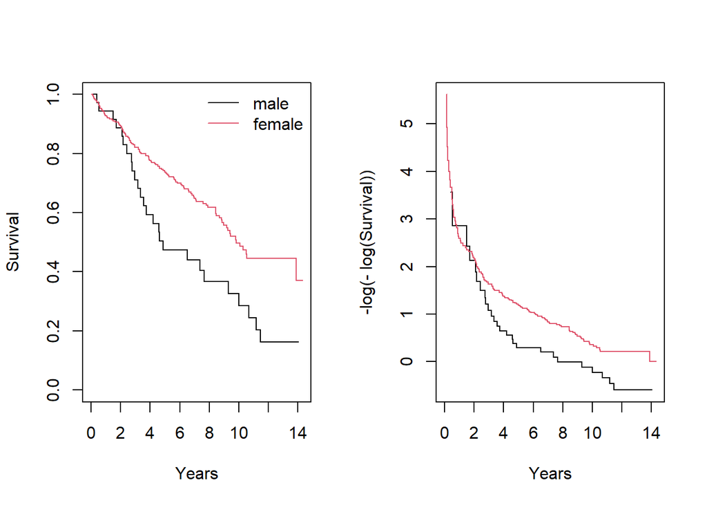

```r
KM_fit <- survfit(Surv(years, status2) ~ sex, data = pbc2.id)

par(mfrow = c(1, 2))

plot(KM_fit, xlab = "Years", ylab = "Survival", col = 1:2)
legend("topright", levels(pbc2.id$sex), lty = 1, col = 1:2, bty = "n")

plot(KM_fit, fun = function (s) -log(-log(s)), xlab = "Years",
    ylab = "-log(- log(Survival))", col = 1:2)
```

For continuous covariates, we can test the proportional hazards assumption using the Schoenfeld residuals. We should note that this procedure also can be used for categorical covariates. We illustrate their use in a Cox model for the PBC dataset that contains `sex`, `age` and their interaction. The model is fitted with the code:

```r
fit <- coxph(Surv(years, status2) ~ sex * age, data = pbc2.id)
```

The function that calculates the Schoenfeld residuals is `cox.zph()`. The two primary arguments of this function are the fitted Cox model and the transformation of time to be used. The code below does the calculations for the KM scale.

```r
check_PH <- cox.zph(fit, transform = "km")
check_PH
```

```
##          chisq df    p
## sex     2.1697  1 0.14
## age     0.0011  1 0.97
## sex:age 1.9059  1 0.17
## GLOBAL  2.1754  3 0.54
```

The output of the function reports a test for non-proportionality (i.e., the null hypothesis is that the corresponding variable satisfies PH). However, it is more useful to inspect the PH assumption by plotting the Schoenfeld residuals graphically. This figure is produced with the `plot()` method. We produce the plot separately for each predictor of the model in order also to include the red line corresponding to PH.

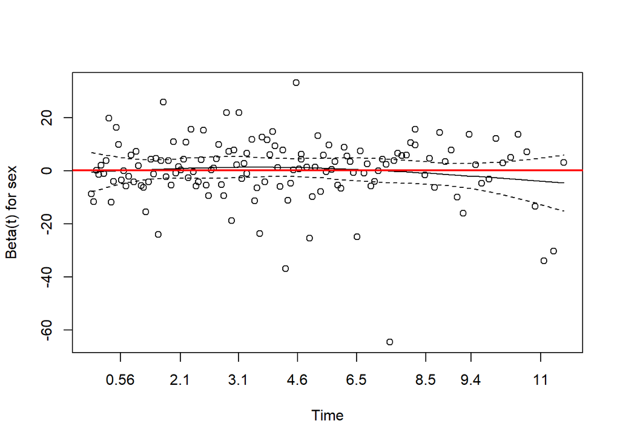

```r
plot(check_PH, var = 1)
abline(h = coef(fit)[1], col = "red", lwd = 2)
```

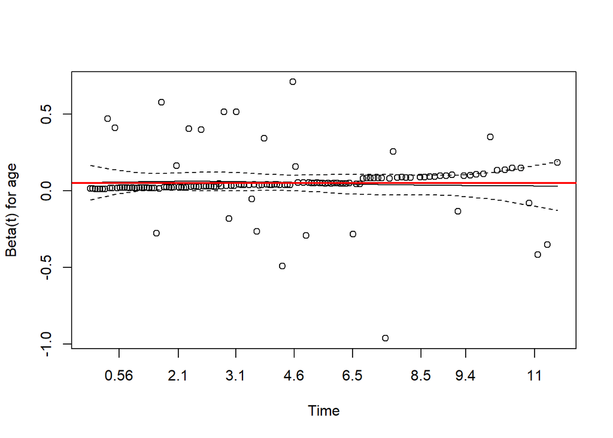

```r
plot(check_PH, var = 2)
abline(h = coef(fit)[2], col = "red", lwd = 2)
```

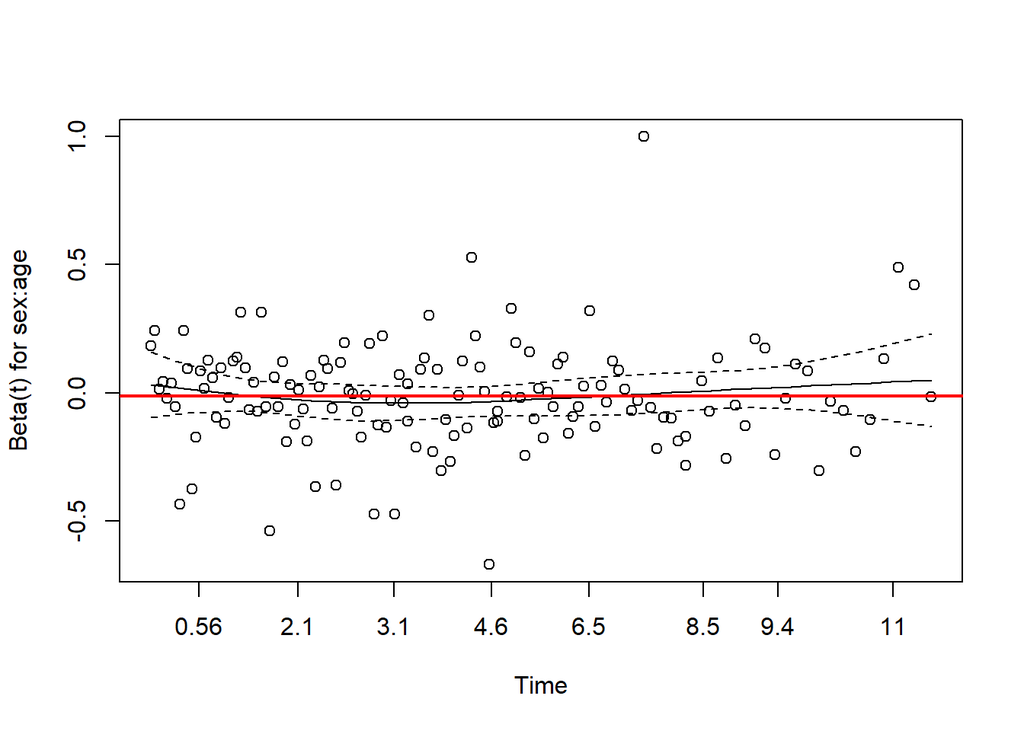

```r
plot(check_PH, var = 3)
abline(h = coef(fit)[3], col = "red", lwd = 2)
```

We observe that for all variables PH seems to hold.

**Notes**

- There is a contradiction with regard to whether the `sex` variable satisfies PH between the first method we have seen based on the transformation of the Kaplan-Meier estimator and the second method based on the Schoenfeld residuals. From the two methods, most trustworthy is the latter.
- From the plots, we observe that the residuals are quite evenly spaced along the x-axis and therefore there is no need to consider other transformations of the timescale.
- Function `cox.zph()` has a logical argument called `terms`, which is by default set to `TRUE`. When `terms = TRUE`, the `cox.zph()` combines the residuals of different coefficients that correspond to the same model term, and produces one plot and one test for zero correlation. This comes into play, for example, when you use splines for a continuous predictor. In this case, the default behavior of `cox.zph()` will combine all spline terms into one plot. If you would like to get the plot per coefficient, you will need to set `terms = FALSE` in the call to `cox.zph()`.

Back to top

# 5 Extensions of the Cox Model

## 5.1 Survival Probabilities from Cox Models

As we have previously explained, the Cox model does not estimate the baseline hazard, and therefore we cannot directly obtain survival probabilities from it. To achieve that we need to combine it with a non-parametric estimator of the baseline hazard function. The most popular method to do that is to use the Breslow estimator. For a fitted Cox model from package **survival** these probabilities are calculated by function `survfit()`. As an illustration, we would like to derive survival probabilities from the following Cox model for the AIDS dataset:

```r
fit <- coxph(Surv(Time, death) ~ CD4 + drug + gender, data = aids.id)
```

Since this model contains three covariates, we need to specify for which combinations of values of these covariates we want to derive the probabilities. These combinations of values need to be specified in a dataset. As an example, we derive survival probabilities for both males and females, who receive both treatments and have square root CD4 equal to 3. The code to create this data uses the `expand.grid()` function that we have seen before:

```r
ND <- with(aids.id, expand.grid(CD4 = 3, drug = levels(drug), gender = levels(gender)))
ND
```

```
##   CD4 drug gender
## 1   3  ddC female
## 2   3  ddI female
## 3   3  ddC   male
## 4   3  ddI   male
```

Then we give the fitted model and the data defined above as arguments to `survfit()`:

```r
surv_probs_Cox <- survfit(fit, newdata = ND)
surv_probs_Cox
```

```
## Call: survfit(formula = fit, newdata = ND)
##
##     n events median 0.95LCL 0.95UCL
## 1 467    188   12.2     9.8      NA
## 2 467    188   10.6     8.0    16.6
## 3 467    188   14.1    11.9    17.8
## 4 467    188   11.6    10.4    14.1
```

The output gives the median survival times and the corresponding 95% confidence intervals for these groups of patients. Similarly to how we worked in Section 2.1, we can derive the survival probabilities at specific follow-up times using the `summary()` method and the `times` argument. For example, the following code extracts the survival probabilities for the groups above at eight months of follow-up:

```r
summary(surv_probs_Cox, times = 8)
```

```
## Call: survfit(formula = fit, newdata = ND)
##
##  time n.risk n.event survival1 survival2 survival3 survival4
##     8    379      86       0.7     0.627     0.747     0.683
```

To obtain the corresponding lower and upper limits of the corresponding 95% confidence intervals, we need to manually extract them from the output of `summary()`, i.e.,

```r
summ <- summary(surv_probs_Cox, times = 8)
out <- t(rbind(summ$surv, summ$lower, summ$upper))
colnames(out) <- c("Surv_Prob", "Lower", "Upper")
out
```

```
##   Surv_Prob     Lower     Upper
## 1 0.6998629 0.5850566 0.8371977
## 2 0.6274689 0.4966114 0.7928075
## 3 0.7471514 0.6894090 0.8097300
## 4 0.6834015 0.6182431 0.7554271
```

Finally, the `plot()` method produces the plot with all four survival curves

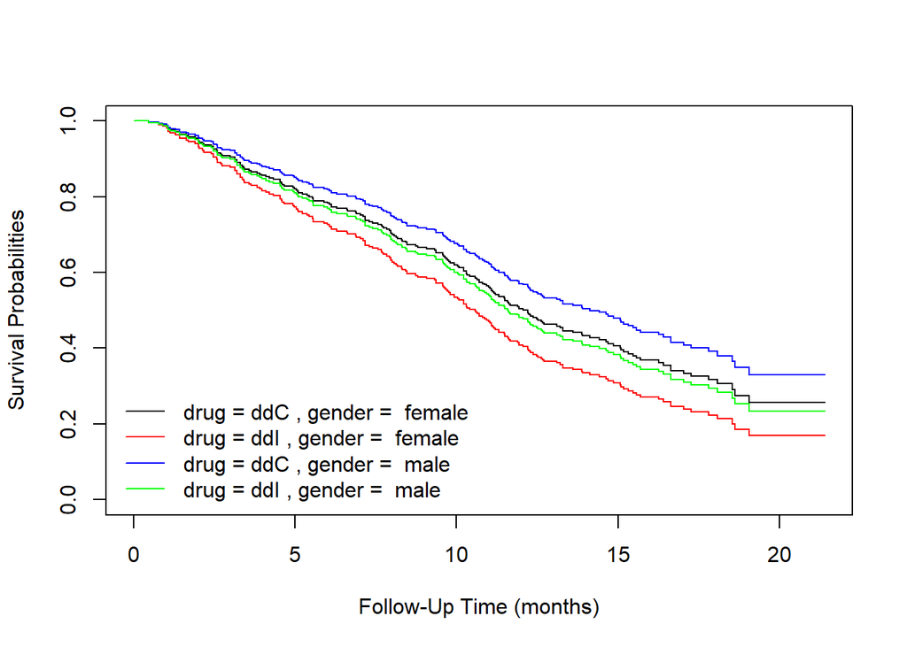

```r
plot(surv_probs_Cox, col = c("black", "red", "blue", "green"),
     xlab = "Follow-Up Time (months)", ylab = "Survival Probabilities")
legend("bottomleft", paste("drug =", ND$drug, ", gender = ", ND$gender),
       lty = 1, col = c("black", "red", "blue", "green"), bty = "n")
```

Back to top

## 5.2 Stratification

In cases, we have inherent heterogeneity in the data (e.g., a multi-center trial) or we have a categorical variable that does not satisfy the proportional hazards assumption, we can use stratification. To fit the stratified Cox model, we include the stratifying factor in the formula of the model using the `strata()` function. For example, the following code fits a stratified Cox model for the PBC dataset with different baseline hazard functions for each `sex`:

```r
fit <- coxph(Surv(years, status2) ~ age + drug + log(serBilir) + strata(sex),
             data = pbc2.id)

summary(fit)
```

```
## Call:
## coxph(formula = Surv(years, status2) ~ age + drug + log(serBilir) +
##     strata(sex), data = pbc2.id)
##
##   n= 312, number of events= 140
##
##                    coef exp(coef)  se(coef)      z Pr(>|z|)
## age            0.048250  1.049433  0.008483  5.688 1.28e-08 ***
## drugD-penicil -0.105392  0.899971  0.177047 -0.595    0.552
## log(serBilir)  1.084214  2.957114  0.094508 11.472  < 2e-16 ***
## ---
## Signif. codes:  0 '***' 0.001 '**' 0.01 '*' 0.05 '.' 0.1 ' ' 1
##
##               exp(coef) exp(-coef) lower .95 upper .95
## age               1.049     0.9529    1.0321     1.067
## drugD-penicil     0.900     1.1111    0.6361     1.273
## log(serBilir)     2.957     0.3382    2.4571     3.559
##
## Concordance= 0.816  (se = 0.021 )
## Likelihood ratio test= 157.3  on 3 df,   p=<2e-16
## Wald test            = 155.7  on 3 df,   p=<2e-16
## Score (logrank) test = 181.6  on 3 df,   p=<2e-16
```

Note, a feature of stratification is that we correct (in the most general manner) the analysis for `sex` but we do not obtain any coefficient for `sex`.

If we would like to allow that the effect of `age` on the log hazard differs between males and females, we include the interaction term between `age` and `strata(sex)`, i.e.,

```r
fit_int <- coxph(Surv(years, status2) ~ age * strata(sex) + drug + log(serBilir),
             data = pbc2.id)

summary(fit_int)
```

```
## Call:
## coxph(formula = Surv(years, status2) ~ age * strata(sex) + drug +
##     log(serBilir), data = pbc2.id)
##
##   n= 312, number of events= 140
##
##                           coef exp(coef) se(coef)      z Pr(>|z|)
## age                    0.03427   1.03487  0.01788  1.917   0.0552 .
## drugD-penicil         -0.11869   0.88809  0.17757 -0.668   0.5039
## log(serBilir)          1.09558   2.99091  0.09526 11.501   <2e-16 ***
## age:strata(sex)female  0.01800   1.01817  0.02035  0.884   0.3764
## ---
## Signif. codes:  0 '***' 0.001 '**' 0.01 '*' 0.05 '.' 0.1 ' ' 1
##
##                       exp(coef) exp(-coef) lower .95 upper .95
## age                      1.0349     0.9663    0.9992     1.072
## drugD-penicil            0.8881     1.1260    0.6271     1.258
## log(serBilir)            2.9909     0.3343    2.4815     3.605
## age:strata(sex)female    1.0182     0.9822    0.9783     1.060
##
## Concordance= 0.817  (se = 0.021 )
## Likelihood ratio test= 158.1  on 4 df,   p=<2e-16
## Wald test            = 156.8  on 4 df,   p=<2e-16
## Score (logrank) test = 181.9  on 4 df,   p=<2e-16
```

When we calculate survival probabilities (see Section 5.1) from a stratified Cox model, we obtain a different curve per stratum. For example, using the last model, we would like to calculate survival probabilities for the patient with the following characteristics:

```r
ND <- with(pbc2.id, expand.grid(
    age = 60,
    drug = factor("placebo", levels = levels(drug)),
    serBilir = 15,
    sex = factor("male", levels = levels(sex))
))
```

To compute the survival probabilities we use `survfit()` and we plot them using the `plot()` method:

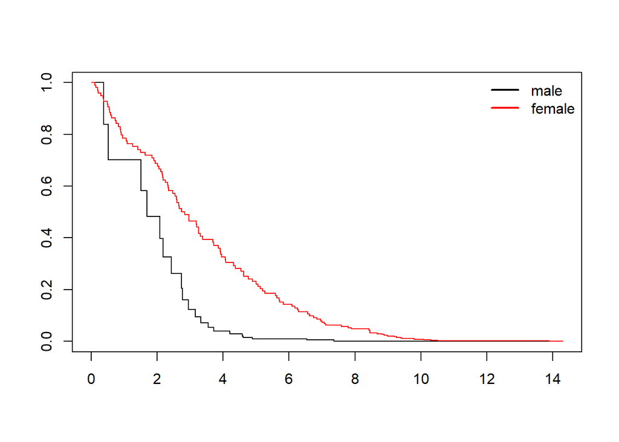

```r
sfit <- survfit(fit_int, newdata = ND)
plot(sfit, col = c("black", "red"))
legend("topright", levels(pbc2.id$sex), lty = 1, lwd = 2, col = c("black", "red"),
       bty = "n")
```

We observe that even though we have specified that the patient for whom we want to calculate survival probabilities is a male, we obtain two curves both for males and females. This is because `sex` is a stratifying factor and not a covariate.

### 5.2.1 Step Functions for Time-Varying Coefficients

```r
fit <- coxph(Surv(time, status) ~ sex + ph.karno, data = lung)
```

As we have seen before in the plot of the Schoefeld residuals, i.e.,

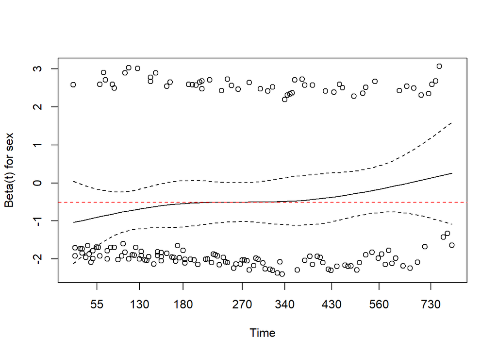

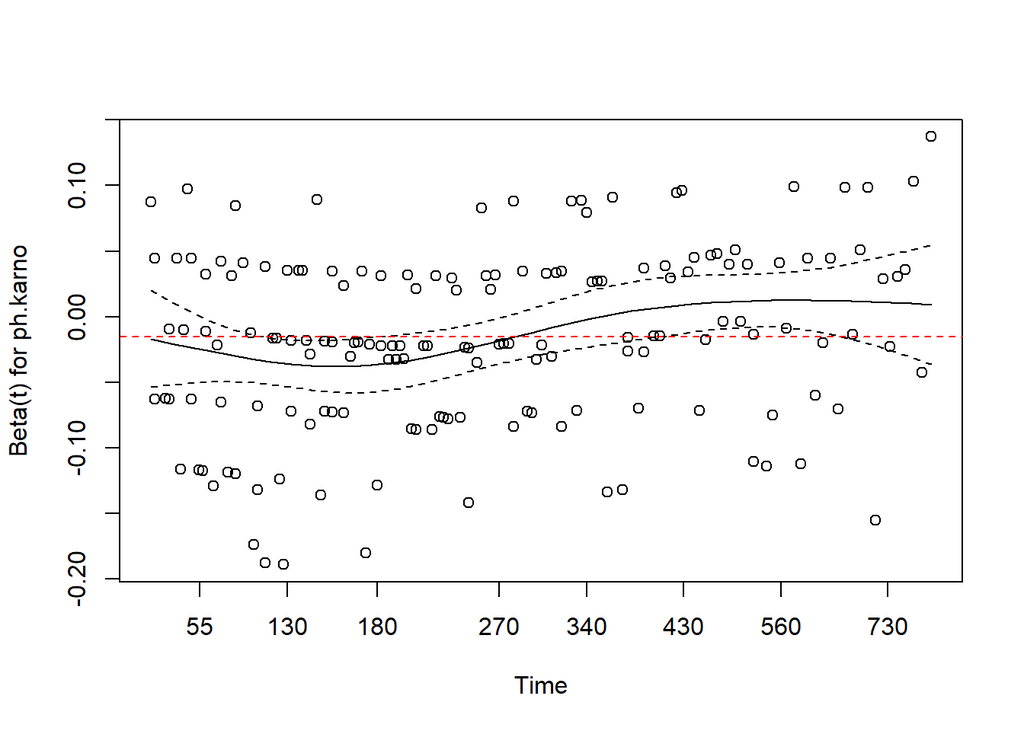

```r
# PH for sex
plot(cox.zph(fit), var = 1)
abline(h = coef(fit)[1], lty = 2, col = "red")

# PH for ph.karno
plot(cox.zph(fit), var = 2)
abline(h = coef(fit)[2], lty = 2, col = "red")
```

there is a very mild violation of PH assumption for `ph.karno` but not for `sex`. Hence, we are going to illustrate how we can relax the PH assumption for `ph.karno` by splitting the follow-up period. Namely, from the figure of the Schoefeld residuals we see that the time-varying coefficient for `ph.karno` seems to be nearly constant in the time periods from 0 to 270 days, and from 270 days to the end of the study. Thus, we will consider these two intervals. We split the original `lung` dataset using the `survSplit()` function. We will need to provide a `formula` that includes the covariates used in the formula of the Cox model (additively with no interactions or nonlinear terms even if you have included such terms in the Cox model), provide the original `lung` data in the `data` argument, then define in the `cut` argument the partition of the time scale, i.e., give the vector `c(270)`, and finally also define the name of the variable that will denote the different pieces of the data.

```r
lung2 <- survSplit(Surv(time, status) ~ sex + ph.karno, data = lung,
                   cut = c(270), episode = "time_group")

head(lung2, 10)
```

```
##     sex ph.karno tstart time status time_group
## 1  male       90      0  270      0          1
## 2  male       90    270  306      1          2
## 3  male       90      0  270      0          1
## 4  male       90    270  455      1          2
## 5  male       90      0  270      0          1
## 6  male       90    270 1010      0          2
## 7  male       90      0  210      1          1
## 8  male      100      0  270      0          1
## 9  male      100    270  883      1          2
## 10 male       50      0  270      0          1
```

Next we fit a stratified Cox model using this newly created dataset. Two notes:

- In the `formula` argument of `coxph()` we will need to include the `tstart`, `time` and `status` variables.
- We will need to stratify the model by the `time_group` variable, and include the interactions of this variable with the covariates for which we want to relax the PH assumption, i.e., here for `ph.karno`

Hence, the code will be

```r
fit_tv_coef <- coxph(Surv(tstart, time, status) ~ sex + ph.karno:strata(time_group),
                     data = lung2)

summary(fit_tv_coef)
```

```
## Call:
## coxph(formula = Surv(tstart, time, status) ~ sex + ph.karno:strata(time_group),
##     data = lung2)
##
##   n= 334, number of events= 164
##
##                                              coef exp(coef)  se(coef)      z
## sexfemale                               -0.520440  0.594259  0.167571 -3.106
## ph.karno:strata(time_group)time_group=1 -0.032412  0.968108  0.007881 -4.113
## ph.karno:strata(time_group)time_group=2  0.002752  1.002756  0.008629  0.319
##                                         Pr(>|z|)
## sexfemale                                 0.0019 **
## ph.karno:strata(time_group)time_group=1 3.91e-05 ***
## ph.karno:strata(time_group)time_group=2   0.7498
## ---
## Signif. codes:  0 '***' 0.001 '**' 0.01 '*' 0.05 '.' 0.1 ' ' 1
##
##                                         exp(coef) exp(-coef) lower .95
## sexfemale                                  0.5943     1.6828    0.4279
## ph.karno:strata(time_group)time_group=1    0.9681     1.0329    0.9533
## ph.karno:strata(time_group)time_group=2    1.0028     0.9973    0.9859
##                                         upper .95
## sexfemale                                  0.8253
## ph.karno:strata(time_group)time_group=1    0.9832
## ph.karno:strata(time_group)time_group=2    1.0199
##
## Concordance= 0.641  (se = 0.025 )
## Likelihood ratio test= 26.3  on 3 df,   p=8e-06
## Wald test            = 27.23  on 3 df,   p=5e-06
## Score (logrank) test = 27.72  on 3 df,   p=4e-06
```

Back to top

## 5.3 Time-Varying Covariates

The association between exogenous time-varying covariates and the risk of an event can be studied using the time-varying Cox model. To fit this model we use the counting process notation that utilizes the intervals created by the time points at which the covariate was recorded. As an illustration, we show how this model can be fitted using the CD4 cell count from the AIDS dataset. We should explicitly note here that this is for illustration purposes since the CD4 cell count is actually an endogenous time-varying covariates. First, let’s have a look at the first rows of the dataset with the start-stop format:

```r
head(aids[c("patient", "start", "stop", "event", "CD4")], 7)
```

```
##   patient start  stop event       CD4
## 1       1     0  6.00     0 10.677078
## 2       1     6 12.00     0  8.426150
## 3       1    12 16.97     0  9.433981
## 4       2     0  6.00     0  6.324555
## 5       2     6 12.00     0  8.124038
## 6       2    12 18.00     0  4.582576
## 7       2    18 19.00     0  5.000000
```

The first patient has three measurements, whereas the second on four. The time-varying Cox model is fitted with the code:

```r
td_Cox <- coxph(Surv(start, stop, event) ~ CD4, data = aids)
summary(td_Cox)
```

```
## Call:
## coxph(formula = Surv(start, stop, event) ~ CD4, data = aids)
##
##   n= 1405, number of events= 188
##
##         coef exp(coef) se(coef)      z Pr(>|z|)
## CD4 -0.19040   0.82663  0.02423 -7.858 3.92e-15 ***
## ---
## Signif. codes:  0 '***' 0.001 '**' 0.01 '*' 0.05 '.' 0.1 ' ' 1
##
##     exp(coef) exp(-coef) lower .95 upper .95
## CD4    0.8266       1.21    0.7883    0.8668
##
## Concordance= 0.691  (se = 0.018 )
## Likelihood ratio test= 90.15  on 1 df,   p=<2e-16
## Wald test            = 61.74  on 1 df,   p=4e-15
## Score (logrank) test = 69.04  on 1 df,   p=<2e-16
```

To more appropriately account for the endogenous nature of the CD4 cell count, we should fit a joint model. This can be done with function `jointModel()` from the **JM** package. This function requires first fitting a linear mixed effects model for the time-varying covariates, a Cox model that may contain other baseline covariates (here we have none), and the we give these two object in the function as main arguments, i.e.,

```r
mixed_model_CD4 <- lme(CD4 ~ obstime, data = aids, random = ~ obstime | patient)
base_Cox <- coxph(Surv(Time, death) ~ 1, data = aids.id, x = TRUE)
joint_model <- jointModel(mixed_model_CD4, base_Cox, timeVar = "obstime",
                          method = "piecewise-PH-aGH")

exp(confint(joint_model, "Event"))
```

```
##            2.5 %      est.    97.5 %
## Assoct 0.6993048 0.7506215 0.8057038
```

We observe that from the Cox model the hazard ratio for a unit increase of the square root CD4 cell count is 0.83 (95% CI: 0.79; 0.87), whereas from the joint model 0.75 (95% CI: 0.70; 0.80). This is a noteworthy difference between the two approaches suggesting that the endogenous nature of the CD4 cell count needs to be taken into account. More information regarding joint models can be found in the end of this document.

Back to top

## 5.4 Clustered Event Time Data

```r
marginal_model <- coxph(Surv(time, status) ~ age + cluster(inst), data = lung)

summary(marginal_model)
```

```
## Call:
## coxph(formula = Surv(time, status) ~ age, data = lung, cluster = inst)
##
##   n= 226, number of events= 163
##    (1 observation deleted due to missingness)
##
##         coef exp(coef) se(coef) robust se     z Pr(>|z|)
## age 0.018726  1.018903 0.009239  0.007096 2.639  0.00831 **
## ---
## Signif. codes:  0 '***' 0.001 '**' 0.01 '*' 0.05 '.' 0.1 ' ' 1
##
##     exp(coef) exp(-coef) lower .95 upper .95
## age     1.019     0.9814     1.005     1.033
##
## Concordance= 0.551  (se = 0.025 )
## Likelihood ratio test= 4.21  on 1 df,   p=0.04
## Wald test            = 6.96  on 1 df,   p=0.008
## Score (logrank) test = 4.12  on 1 df,   p=0.04,   Robust = 3.57  p=0.06
##
##   (Note: the likelihood ratio and score tests assume independence of
##      observations within a cluster, the Wald and robust score tests do not).
```

We observe that there is an extra column in the output with the robust (jackknife-corrected) standard errors. The reported p-values are based on those robust standard errors.

When instead the focus is on inferences within the clusters, or we are interested in quantifying the heterogeneity between the clusters, the frailty/conditional approach should be used. In this approach, we assume that there is an unobserved variable which all members within a cluster share. Due to the sharing of this variable correlation is generated. To fit a frailty model for the Lung data, we use function `frailty()` and the following call to `coxph()`:

```r
frailty_model <- coxph(Surv(time, status) ~ age + frailty(inst),
    data = lung)

summary(frailty_model)
```

```
## Call:
## coxph(formula = Surv(time, status) ~ age + frailty(inst), data = lung)
##
##   n= 226, number of events= 163
##    (1 observation deleted due to missingness)
##
##               coef    se(coef) se2      Chisq DF p
## age           0.01873 0.009239 0.009239 4.11  1  0.043
## frailty(inst)                           0.00  0  0.920
##
##     exp(coef) exp(-coef) lower .95 upper .95
## age     1.019     0.9814     1.001     1.038
##
## Iterations: 6 outer, 20 Newton-Raphson
##      Variance of random effect= 5e-07   I-likelihood = -737.3
## Degrees of freedom for terms= 1 0
## Concordance= 0.554  (se = 0.025 )
## Likelihood ratio test= 4.21  on 1 df,   p=0.04
```

In this particular example, we observe that the heterogeneity between the different institutions (quantified by the variance of the frailty term) is rather minimal.

Back to top

## 5.5 Competing Risks

In settings in which we have multiple correlated types of events occurring to the patients, and we are not (only) interested in the composite event, we will need to account for the competing risks problem. In cases of competing risks, the classical Kaplan-Meier estimator (i.e., treating the other event as censored), gives biased estimates of cumulative incidences (cumulative incidence equals one minus the survival probability that we get from the Kaplan-Meier estimator). To obtain unbiased estimates of the cumulative incidence function per type of event, we will need to account for the competition between them. A non-parametric estimator of these functions is obtained using function `survfit()`. As an example, we illustrate its use in the PBC dataset in which some patients died, and some received a liver transplant. To appropriately account for competing risks we need two event indicators, the indicator of each risk, this is variable `status` in the `pbc2.id` dataset, and the indicator of any event. We construct this variable, named `status3`, with the following line of code:

```r
pbc2.id$status3 <- as.numeric(pbc2.id$status != "alive")
```

Using these two variables, unbiased estimates of the cumulative incidence functions are obtained with the following call to `survfit()`,

```r
fit <- survfit(Surv(years, status3) ~ 1, data = pbc2.id, etype = status)
```

We plot these estimated functions with the `plot()` method:

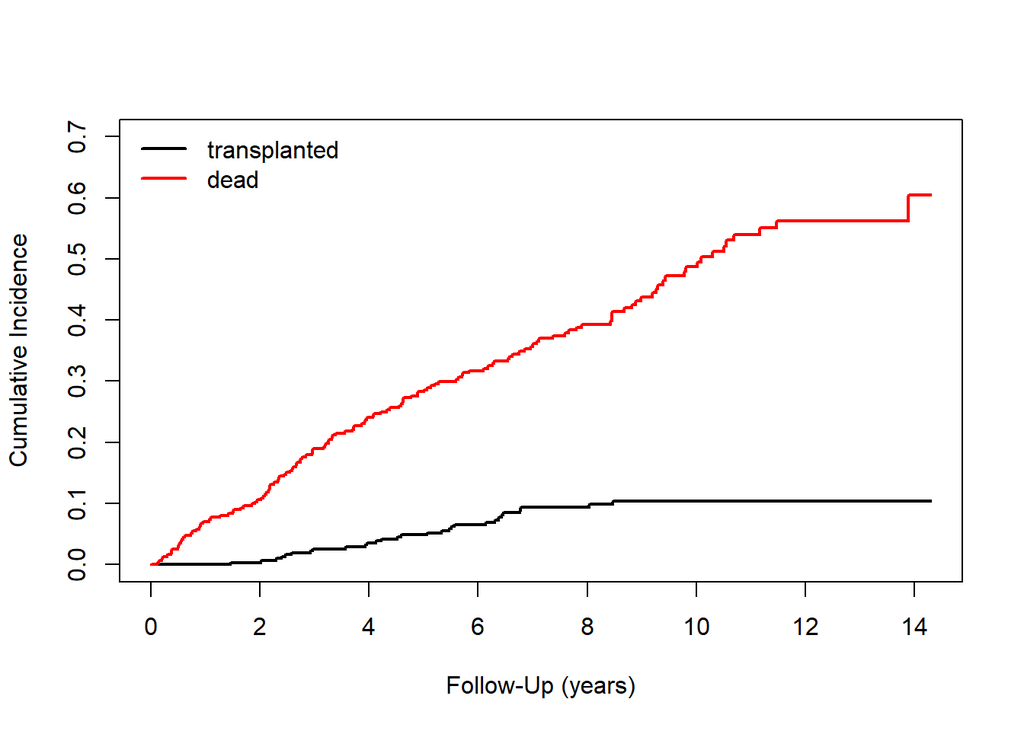

```r
plot(fit, fun = "event", col = c("black", "red"), lwd = 2, ylim = c(0, 0.7),
     xlab = "Follow-Up (years)", ylab = "Cumulative Incidence")
legend("topleft", levels(pbc2.id$status)[2:3], lty = 1, lwd = 2, col = c("black", "red"),
       bty = "n")
```

Contrary to the Kaplan-Meier estimator, the Cox model and because of the use of the partial likelihood provides correct hazard ratios in the context of competing risks by treating the other event as censored. Though these hazard ratios cannot be readily transformed to cumulative incidences by directly using the Breslow estimator of Section 5.1. Following on the PBC dataset, we fit cause-specific hazard regression models for transplanted and dead patients:

```r
fit1 <- coxph(Surv(years, status == "transplanted") ~ drug + age,
    data = pbc2.id)
summary(fit1)
```

```
## Call:
## coxph(formula = Surv(years, status == "transplanted") ~ drug +
##     age, data = pbc2.id)
##
##   n= 312, number of events= 29
##
##                   coef exp(coef) se(coef)      z Pr(>|z|)
## drugD-penicil -0.23680   0.78915  0.37723 -0.628     0.53
## age           -0.09649   0.90802  0.02265 -4.259 2.05e-05 ***
## ---
## Signif. codes:  0 '***' 0.001 '**' 0.01 '*' 0.05 '.' 0.1 ' ' 1
##
##               exp(coef) exp(-coef) lower .95 upper .95
## drugD-penicil    0.7891      1.267    0.3768    1.6530
## age              0.9080      1.101    0.8686    0.9492
##
## Concordance= 0.73  (se = 0.042 )
## Likelihood ratio test= 22.32  on 2 df,   p=1e-05
## Wald test            = 18.54  on 2 df,   p=9e-05
## Score (logrank) test = 20.1  on 2 df,   p=4e-05
```

```r
fit2 <- coxph(Surv(years, status == "dead") ~ drug + age, data = pbc2.id)
summary(fit2)
```

```
## Call:
## coxph(formula = Surv(years, status == "dead") ~ drug + age, data = pbc2.id)
##
##   n= 312, number of events= 140
##
##                    coef exp(coef)  se(coef)      z Pr(>|z|)
## drugD-penicil -0.162071  0.850380  0.172501 -0.940    0.347
## age            0.045718  1.046780  0.008487  5.387 7.16e-08 ***
## ---
## Signif. codes:  0 '***' 0.001 '**' 0.01 '*' 0.05 '.' 0.1 ' ' 1
##
##               exp(coef) exp(-coef) lower .95 upper .95
## drugD-penicil    0.8504     1.1759    0.6064     1.192
## age              1.0468     0.9553    1.0295     1.064
##
## Concordance= 0.629  (se = 0.024 )
## Likelihood ratio test= 29.15  on 2 df,   p=5e-07
## Wald test            = 29.04  on 2 df,   p=5e-07
## Score (logrank) test = 29.47  on 2 df,   p=4e-07
```

An alternative framework for competing risks analysis that directly gives results on the cumulative incidence functions scale is the Fine-Gray model. This can be fitted with package [**cmprsk**](https://cran.r-project.org/package=cmprsk). Additional information also in the package [**mstate**](https://cran.r-project.org/package=mstate).

Back to top

# 6 6. Extra Material

- [Survival analysis basics](https://www.r-bloggers.com/survival-analysis-basics/)
- [Survival analysis in R (1)](https://www.r-bloggers.com/survival-analysis-with-r/)
- [Survival analysis in R (2)](https://www.openintro.org/stat/surv.php)
- [Survival analysis in R (3)](https://rpubs.com/daspringate/survival)
- [JM package](http://www.jstatsoft.org/v35/i09/)
- [JMbayes package](http://dx.doi.org/10.18637/jss.v072.i07)
- [Joint models book](http://www.crcpress.com/product/isbn/9781439872864)
- [Code from Joint Models book](http://jmr.r-forge.r-project.org/)

Back to top